# Project_Stage_2_Individual_Work_Kevin_Hayes

## - Plot weekly trends (cases and deaths) for the top 5 infected counties. Show plots by raw values and log normalized values. Describe what is causing them and what were the peaks. Do the counties follow state pattern.

```python
index = fl_total_deaths.index

index = list(index)

index
```

```
[372, 379, 335, 381, 357]
```

```python
fl_counties_cases = fl_cases.loc[index]

fl_counties_cases
```

|  | countyFIPS | County Name | State | StateFIPS | 2020-01-22 | 2020-01-23 | 2020-01-24 | 2020-01-25 | 2020-01-26 | 2020-01-27 | ... | 2023-07-14 | 2023-07-15 | 2023-07-16 | 2023-07-17 | 2023-07-18 | 2023-07-19 | 2023-07-20 | 2023-07-21 | 2023-07-22 | 2023-07-23 |
| --- | --- | --- | --- | --- | --- | --- | --- | --- | --- | --- | --- | --- | --- | --- | --- | --- | --- | --- | --- | --- | --- |
| 372 | 12086 | Miami-Dade County | FL | 12 | 0 | 0 | 0 | 0 | 0 | 0 | ... | 1560492 | 1560492 | 1560492 | 1560492 | 1560492 | 1560492 | 1560492 | 1560492 | 1560492 | 1560492 |
| 379 | 12099 | Palm Beach County | FL | 12 | 0 | 0 | 0 | 0 | 0 | 0 | ... | 486711 | 486711 | 486711 | 486711 | 486711 | 486711 | 486711 | 486711 | 486711 | 486711 |
| 335 | 12011 | Broward County | FL | 12 | 0 | 0 | 0 | 0 | 0 | 0 | ... | 781299 | 781299 | 781299 | 781299 | 781299 | 781299 | 781299 | 781299 | 781299 | 781299 |
| 381 | 12103 | Pinellas County | FL | 12 | 0 | 0 | 0 | 0 | 0 | 0 | ... | 279828 | 279828 | 279828 | 279828 | 279828 | 279828 | 279828 | 279828 | 279828 | 279828 |
| 357 | 12057 | Hillsborough County | FL | 12 | 0 | 0 | 0 | 0 | 0 | 0 | ... | 485408 | 485408 | 485408 | 485408 | 485408 | 485408 | 485408 | 485408 | 485408 | 485408 |

5 rows × 1269 columns

```python
fl_counties_cases_dates = get_dates(fl_counties_cases)

fl_counties_cases_dates
```

|  | 2020-07-06 | 2020-07-07 | 2020-07-08 | 2020-07-09 | 2020-07-10 | 2020-07-11 | 2020-07-12 | 2020-07-13 | 2020-07-14 | 2020-07-15 | ... | 2020-12-18 | 2020-12-19 | 2020-12-20 | 2020-12-21 | 2020-12-22 | 2020-12-23 | 2020-12-24 | 2020-12-25 | 2020-12-26 | 2020-12-27 |
| --- | --- | --- | --- | --- | --- | --- | --- | --- | --- | --- | --- | --- | --- | --- | --- | --- | --- | --- | --- | --- | --- |
| 372 | 48992 | 51058 | 53974 | 55961 | 58341 | 60868 | 64444 | 67713 | 69803 | 72317 | ... | 269716 | 272098 | 274117 | 276414 | 278739 | 280982 | 283285 | 283285 | 286662 | 288306 |
| 379 | 17242 | 17638 | 18231 | 18656 | 19233 | 19847 | 21018 | 21806 | 22279 | 22788 | ... | 75572 | 76143 | 76602 | 77241 | 77743 | 78187 | 78852 | 78852 | 79830 | 80239 |
| 335 | 21856 | 22595 | 23781 | 25102 | 26705 | 28253 | 30025 | 31484 | 32814 | 34153 | ... | 125338 | 126402 | 127240 | 128157 | 128963 | 129897 | 130978 | 130978 | 132193 | 132897 |
| 381 | 8759 | 9032 | 9395 | 9826 | 10293 | 10596 | 10844 | 11442 | 11754 | 12080 | ... | 39846 | 40299 | 40560 | 40987 | 41280 | 41654 | 42176 | 42176 | 42973 | 43210 |
| 357 | 14677 | 15362 | 16099 | 16666 | 17662 | 18360 | 19150 | 19828 | 20508 | 21018 | ... | 68739 | 69530 | 70027 | 70849 | 71388 | 71957 | 72860 | 72860 | 73980 | 74368 |

5 rows × 175 columns

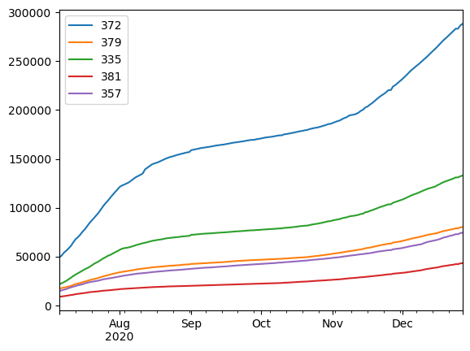

```python
fl_counties_cases_dates.T.plot(title = "FL raw cases")
```

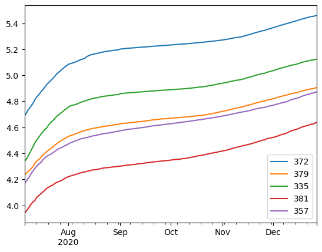

```python
fl_counties_cases_dates.apply(np.log10).T.plot("FL log cases")
```

```python
fl_counties_deaths = fl_deaths.loc[index]

fl_counties_deaths
```

|  | countyFIPS | County Name | State | StateFIPS | 2020-01-22 | 2020-01-23 | 2020-01-24 | 2020-01-25 | 2020-01-26 | 2020-01-27 | ... | 2023-07-14 | 2023-07-15 | 2023-07-16 | 2023-07-17 | 2023-07-18 | 2023-07-19 | 2023-07-20 | 2023-07-21 | 2023-07-22 | 2023-07-23 |
| --- | --- | --- | --- | --- | --- | --- | --- | --- | --- | --- | --- | --- | --- | --- | --- | --- | --- | --- | --- | --- | --- |
| 372 | 12086 | Miami-Dade County | FL | 12 | 0 | 0 | 0 | 0 | 0 | 0 | ... | 6472 | 6472 | 6472 | 6472 | 6472 | 6472 | 6472 | 6472 | 6472 | 6472 |
| 379 | 12099 | Palm Beach County | FL | 12 | 0 | 0 | 0 | 0 | 0 | 0 | ... | 2883 | 2883 | 2883 | 2883 | 2883 | 2883 | 2883 | 2883 | 2883 | 2883 |
| 335 | 12011 | Broward County | FL | 12 | 0 | 0 | 0 | 0 | 0 | 0 | ... | 3079 | 3079 | 3079 | 3079 | 3079 | 3079 | 3079 | 3079 | 3079 | 3079 |
| 381 | 12103 | Pinellas County | FL | 12 | 0 | 0 | 0 | 0 | 0 | 0 | ... | 1671 | 1671 | 1671 | 1671 | 1671 | 1671 | 1671 | 1671 | 1671 | 1671 |
| 357 | 12057 | Hillsborough County | FL | 12 | 0 | 0 | 0 | 0 | 0 | 0 | ... | 1832 | 1832 | 1832 | 1832 | 1832 | 1832 | 1832 | 1832 | 1832 | 1832 |

5 rows × 1269 columns

```python
fl_counties_deaths_dates = get_dates(fl_counties_deaths)

fl_counties_deaths_dates
```

|  | 2020-07-06 | 2020-07-07 | 2020-07-08 | 2020-07-09 | 2020-07-10 | 2020-07-11 | 2020-07-12 | 2020-07-13 | 2020-07-14 | 2020-07-15 | ... | 2020-12-18 | 2020-12-19 | 2020-12-20 | 2020-12-21 | 2020-12-22 | 2020-12-23 | 2020-12-24 | 2020-12-25 | 2020-12-26 | 2020-12-27 |
| --- | --- | --- | --- | --- | --- | --- | --- | --- | --- | --- | --- | --- | --- | --- | --- | --- | --- | --- | --- | --- | --- |
| 372 | 1051 | 1057 | 1068 | 1092 | 1118 | 1132 | 1139 | 1143 | 1175 | 1202 | ... | 4034 | 4050 | 4066 | 4095 | 4095 | 4096 | 4108 | 4108 | 4127 | 4150 |
| 379 | 543 | 563 | 569 | 578 | 586 | 594 | 606 | 611 | 624 | 634 | ... | 1816 | 1816 | 1819 | 1835 | 1835 | 1842 | 1858 | 1858 | 1860 | 1860 |
| 335 | 414 | 418 | 419 | 427 | 438 | 455 | 464 | 464 | 464 | 464 | ... | 1763 | 1768 | 1776 | 1784 | 1792 | 1796 | 1798 | 1798 | 1811 | 1817 |
| 381 | 199 | 206 | 209 | 221 | 223 | 229 | 229 | 236 | 262 | 278 | ... | 995 | 996 | 997 | 999 | 1000 | 1007 | 1013 | 1013 | 1020 | 1029 |
| 357 | 158 | 163 | 163 | 182 | 186 | 187 | 188 | 188 | 189 | 192 | ... | 1021 | 1023 | 1026 | 1034 | 1038 | 1046 | 1056 | 1056 | 1058 | 1058 |

5 rows × 175 columns

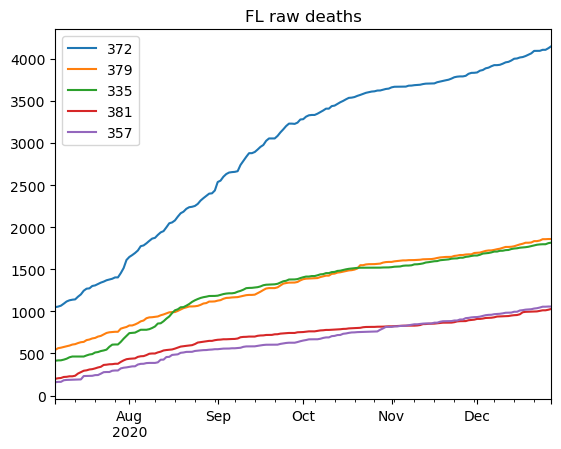

```python
fl_counties_deaths_dates.T.plot(title = "FL raw deaths")
```

[figure not shown]

```python
fl_counties_cases_dates.apply(np.log10).T.plot(title = "FL log deaths")
```

### Everything looks very uniform outside of a spike in deaths in county 372 (Miami-Dade County) that starts in Aug 2020.

##### Quick reaserch also finds a massive spike in reported cases during january 2022, but that is outside of the scope of our data.

```python
deaths.loc[372]["County Name"]
```

```
'Miami-Dade County '
```

### According to https://www.local10.com/news/local/2020/08/12/coronavirus-florida-latest-case-total-covid-19-deaths/, This spike in deaths is due to a data backlog rather than an actual real world event.

## Outside of the stated reporting issue, the selected counties do follow the same patterns as the state as a whole.